# Online E-commerce Data Analysis. 1. Introduction | by Abhilash Singh | Medium

# Online E-commerce Data Analysis

Abhilash Singh

Jul 29, 2020·15 min read

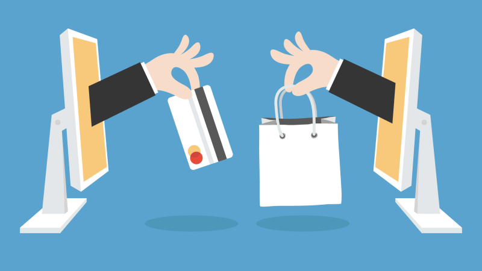

# 1. Introduction

More customers mean more business. Intuitively, it is safe to assume that a company’s ability to attract increasing number of customers has a direct relationship to its increasing sales. However, simply increasing the number of customer base can prove to be a vanity metric, meaning that it would not fulfill its ability to drive business. Moreover, acquiring or keeping the right customers can prove to be more effective in increasing the sales along with saving money instead of mindlessly spending resources on lost causes.

With the help of our data, we would try to generate insights aiding in a successful wholesale channel. The dataset which we will be analyzing is for a UK-based online retail store which majorly sells gift products. The customer base of the company are mainly wholesale retailers. These wholesalers are entities buying products in bulk, generally with a low price tag.

To implement a successful wholesale strategy, let us inspect our data and learn what could be a potential plan of action to drive the business.

Following is a quick walkthrough to the whole analysis done in Python. For more information on the codes, please find the project on my [GitHub](https://github.com/abhilashsinghcad).

# 2. Data Cleaning

The online retail dataset and its related information can be found [here](https://archive.ics.uci.edu/ml/datasets/online+retail).

```
df ----> Our DataFrame
```

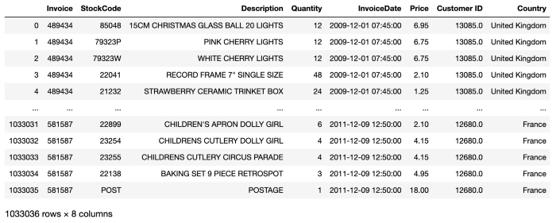

The dataset has 8 attributes ranging from Invoice (Invoice Number), StockCode (Product Item Code), Description (Product Name), Quantity (Number of items bought), InvoiceDate (Time of Purchase), Customer ID (Unique Customer Identification), Price (Price in Pounds), and Country (Place of Transaction). Additionally, the dataset is supposedly large with 1033036 instances.

```
df.info()<class 'pandas.core.frame.DataFrame'>
RangeIndex: 1033036 entries, 0 to 1033035
Data columns (total 8 columns):
Invoice        1033036 non-null object
StockCode      1033036 non-null object
Description    1028761 non-null object
Quantity       1033036 non-null int64
InvoiceDate    1033036 non-null datetime64[ns]
Price          1033036 non-null float64
Customer ID    797885 non-null float64
Country        1033036 non-null object
dtypes: datetime64[ns](1), float64(2), int64(1), object(4)
memory usage: 63.1+ MB
```

There is a significant portion of transactions having missing customer ids. We can’t completely neglect these transactional fields as they might be important in other purposes. For now, let us keep it as it is.

```
# Cancelled Orders - Does not count towards the revenue stream.
------------------------------------------------------------cancel_df = df[df['Invoice'].str.contains('C', na = False)]
cancel_df.reset_index(drop=True)
```

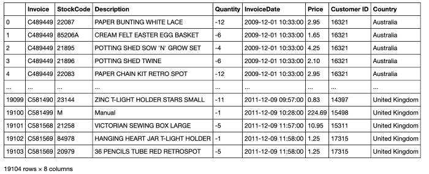

[figure not shown]

Invoices starting with ‘C’ are cancelled orders. As they do not count towards the revenue stream, we can remove these transactional fields from the data. Similarly, few transactions with Invoice Code starting with ‘A’ are associated to bad debt adjustments.

**What Is a Bad Debt Expense?**

"A bad debt expense is recognized when a receivable is no longer collectible because a customer is unable to fulfill their obligation to pay an outstanding debt due to bankruptcy or other financial problems. Companies that extend credit to their customers report bad debts as an allowance for doubtful accounts on the balance sheet, which is also known as a provision for credit losses."

**Cleaned Dataset**

```
# Removing Unwanted Transactions
------------------------------------trans_df = df[~df['Invoice'].str.contains('C', na = False)]

trans_df.loc[:,'Revenue'] = np.nan

trans_df.loc[:,'Revenue']= trans_df.loc[:,'Quantity']*trans_df.loc[:,'Price']

trans_df.reset_index(drop=True)trans_df = trans_df[~trans_df.Invoice.str.contains('A', na = False)]
trans_df = trans_df[trans_df['Price']!=0]
trans_df.reset_index(drop=True)
```

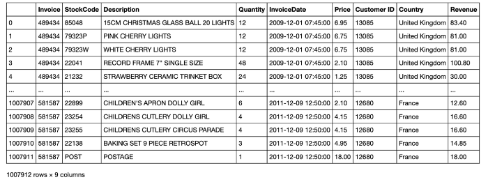

Ultimately, after removing the unnecessary fields related to cancelled orders and credit adjustments, we’ve done some basic cleaning prior to our exploration and have obtained a dataset where the transactions are actually adding to the revenue stream. Nonetheless, we might need to clean it frequently as we further delve into the data.

# **3. Data Exploration**

## 3.1 Frequently Purchased Products:

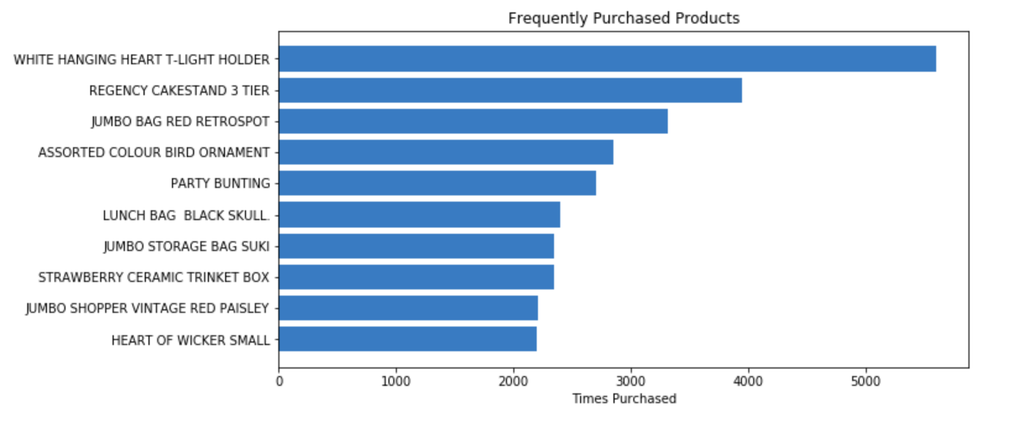

## 3.2 Purchases by Time:

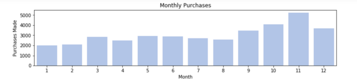

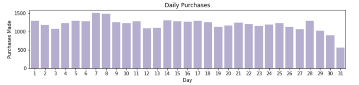

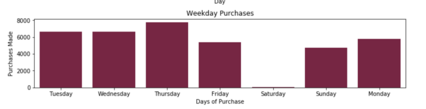

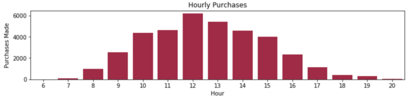

Insights:

a) Number of purchases tend to increase during the holiday season. It is not unusual that gift products demand is higher in the final quarter of the year. Additionally, there might be a possibility that the retail customers tend to stockpile gift supplies during these times as the price of products might be relatively down.

b) There is no clear correlation among the days of the month and the number of purchases made.

c) Surprisingly, there are almost no purchases made on saturdays with weaker sales on weekends. What could be the reason ? Is the e-commerce site blocking the listing of the seller on Saturdays? Strange!

d) The hours of purchases are probably along the same lines as of the retailers’ operating hours.

## 3.3 Country:

The proportion of purchases made within United Kingdom.

```
United Kingdom    0.918768
Name: Country, dtype: float64
```

Almost 92 % purchases are made within United Kingdom itself. As a matter of fact, the product supplies reach faster and products’ deliveries are reliable within the same region. This could be confirmed with the analysis of the cancelled orders.

Additionally, the cost to ship within the same country is definitely low.

# 4. Understanding Customer Metrics

```
# Almost 90% of the transactions are from United Kingdom.# Let us filter the United Kingdom transactions with known customer IDs.uk_df = trans_df[(trans_df['Country']=='United Kingdom') & (trans_df['Customer ID']!=-1)]
uk_df.reset_index(drop=True, inplace = True)uk_df['Price'].describe()count    700388.000000
mean          3.065463
std          25.598485
min           0.001000
25%           1.250000
50%           1.950000
75%           3.750000
max       10953.500000
Name: Price, dtype: float64
```

```
# lets plot a boxplot without statistical outlierssns.boxplot(uk_df['Price'], showfliers = False)
```

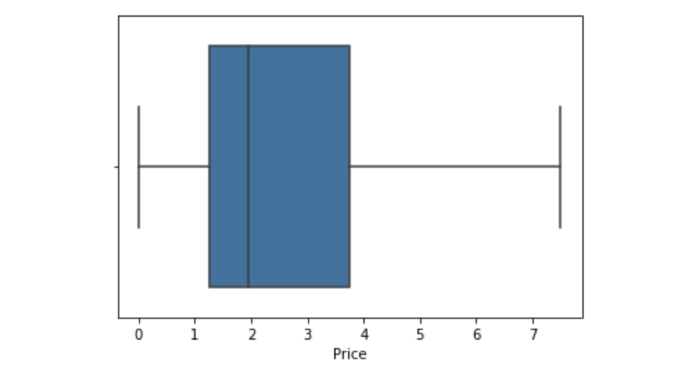

```
low_price_perc = uk_df[uk_df['Price'<=8].shape[0]/uk_df['Price'].shape[0]*100print("{:.2f} % of the transactions made were less than 8 pounds.".format(low_price_perc))93.82 % of the transactions made were less than 8 pounds.
```

93.82 % of the transactions made were less than 8 pounds.

```
low_price_rev = np.sum(uk_df[uk_df['Price']<=8].Revenue)/np.sum(uk_df.Revenue)*100print("{:.2f} % of the revenue is contributed by those products.".format(low_price_rev))88.85 % of the revenue is contributed by those products.
```

88.85% of the revenue is contributed by those products.

As the prices of the products within our large dataset are too low (8 pounds) and the proportion of those products is too high, any major outlier would hardly skew our mean.

## 4.1 Classifying Customers

[output not shown]

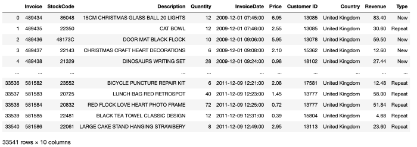

In the classification done above based upon the time of purchases, a customer making the very first purchase will be classified as ‘New’ and for every subsequent purchase made after that with a new invoice, the customer will be classified as a ‘Repeat’ purchaser.

## 4.2 Monthly New Customer Rate and Monthly Repeat Purchase Rate

```
fig, ax = plt.subplots(1,2, figsize =(15,3))monthly_new = monthly_cust['New']
monthly_total = cust_type.groupby('YM')['Customer ID'].nunique()
acquisition = (monthly_new/monthly_total)*100ax[0].plot(acquisition[1:])
ax[0].tick_params('x',labelrotation=45)
ax[0].set_xlabel('Time (Months)')
ax[0].set_title('New Customer Rate')
ax[0].set_ylabel('Percentage of Customers')ax[1].plot(((monthly_cust['Repeat']/monthly_total)*100), color = 'orange')
ax[1].tick_params('x',labelrotation=45)
ax[1].set_xlabel('Time (Months)')
ax[1].set_title('Repeat Purchase Rate')
ax[1].set_ylabel('Percentage of Customers')sns.despine(bottom=False, left=False, ax=ax[0])
sns.despine(bottom=False, left=False, ax=ax[1])
```

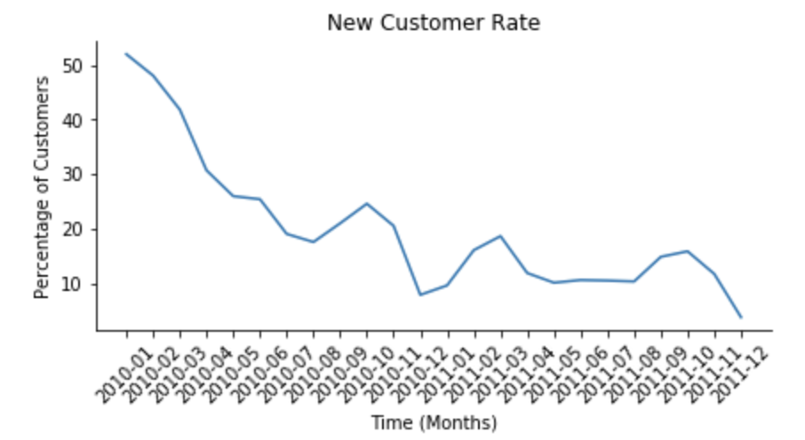

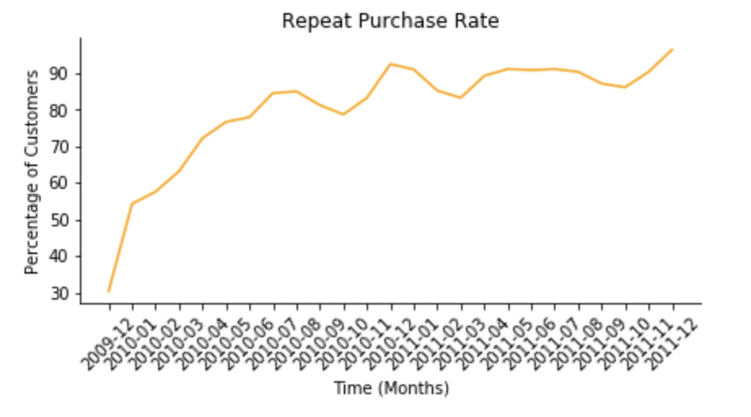

Out of all monthly unique customers buying from our online store, the proportion of new customers buying every month shows a decreasing trend. Maybe these new customers have a tendency to become repeat purchasers in future. The store seems to be efficient in retaining the customers.

As per our dataset, suppose the store started its operations from December 2009, the repeat purchase rate seems to be trending upwards. This suggests that our customer base is growing slowly but the possibility of customers coming to buy again is relatively high. In a way, enhancing the customer acquisition strategy and retaining those customers for a longer period can prove to be more beneficial.

Stores having a wide variety of products catalogue tend to have a higher repeat purchase rate. Customers have varied options to choose from the product offerings, increasing the repeat purchases.

## 4.3 Average Order Value

```
# Monthly Average Order Valueaov = (join.groupby(['YM','Type']).Revenue_x.sum().unstack()/join.groupby(['YM','Type']).Invoice.nunique().unstack())
plt.figure(figsize=(10,5))
plt.plot(aov, )
plt.legend(['New', 'Repeat'])
plt.xlabel('Months')
plt.ylabel('Average Order Value')
plt.xticks(rotation = 45)
plt.title('MONTHLY AVERAGE ORDER VALUE')
plt.ylim(0,1000)# Boxplotym_type = join.groupby(['YM','Type']).Revenue_x.sum().unstack()/join.groupby(['YM','Type']).Invoice.nunique().unstack()
sns.boxplot(x='Type', y='value', data = pd.melt(ym_type))
plt.xlabel('Customer Type')
plt.ylabel('Average Order Value')
plt.title('MONTHLY AVERAGE ORDER VALUE')
```

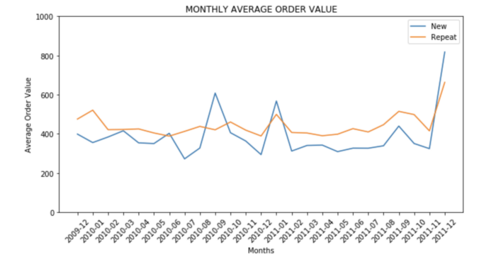

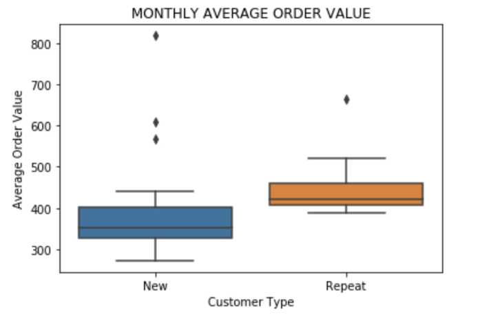

The monthly average revenue of repeat purchasers tends to be more than that of new ones. Maybe, the repeat purchasers have developed a level of trust making them to spend more in our online store. New customers might refrain from making higher quantity orders while buying for the first time. Ultimately, statistical tests could be run to confirm whether these differences are practically significant or not.

## 4.4 Customer Lifetime Value

Customers tend to be of more value when they stay with the business for a longer period. Customer loyalty is one of the predictors driving the value of customers in businesses. Every business has its own way of calculating lifetime value.

If we can know the cost that goes into acquiring a customer, then the customer lifetime value becomes a more valuable metric in knowing whether we must continue to pursue new customers while still being profitable.

With our current data we will try to calculate the lifetime value with a simple formula.

## Customer Lifetime Value (CLV) = Average Order Value(AOS) * Average Order Frequency(AOF) * Average Customer Lifespan(ACL)

## i) CLV for Average Customer

## a) Average Order Size (AOS)

“The average order size (AOS) is the average amount of money that a customer spends each time they place an order. The average order size is calculated by calculating your total customer revenue for a given period and dividing the total orders performed by these customers to calculate your average order size.”

```
aos = join.Revenue_x.sum()/len(join['Invoice'].unique())
aosOutput: 429
```

The bill value per invoice is around 429 pounds.

## b) Average Order Frequency (AOF)

“The average order frequency (AOF) represents the average amount of orders placed by each customer. Your average order frequency (AOF) is calculated by compiling the total number of orders for a given period and dividing it by the total number of customers for a given period.”

```
aof = (len(join['Invoice'].unique()))/(len(join['Customer ID_x'].unique()))print("{:.2f}".format(aof))Output:6.27
```

The average of a customer making an unique purchase is approximately 6 times. However, for this particular calculation, we are considering both new and repeat puchasers and the average frequency of repeat purchasers is expected to be more than this value.

## c) Average Customer Value (ACV)

“The average customer value (ACV) is the average revenue value that each customer brings to your business during a given timeframe. The average customer value can be determined by multiplying the average order size (AOS) with the average order frequency (AOF).”

```
acv = (aos*aof)/2print("Average Customer Value Per Year is {:.2f} Pounds.".format(acv))Output:Average Customer Value Per Year is 1344.79 Pounds.
```

As we have two years of data, we divide the average value by 2.

## d) Average Customer Lifespan (ACL)

“The average customer lifespan is the average number of days between first order date and last order date of all of your customers.”

```
total_days = np.sum((cust_type.groupby('Customer ID').InvoiceDate.max() - cust_type.groupby('Customer ID').InvoiceDate.min()).dt.days)Output: total_days = 1475507
total_cust = len(cust_type['Customer ID'].unique())Output: total_cust = 5350
acl = (total_days/total_cust)/365
print("Average Customer Lifespan Per Year is {:.2f}.".format(acl))Output:
Average Customer Lifespan Per Year is 0.76.
```

The average duration a customer stays with the business is around 9 months (12*0.76).

## e) Customer Lifetime Value (CLV)

“To calculate your average customer lifetime value (CLV) using this simple method, multiply your average customer lifespan (ACL) to your average customer value (ACV).”

```
clv = acl*acv
print("Average Customer Lifetime Value is {:.2f}.".format(clv))Output:
Average Customer Lifetime Value is 1016.13.
```

Customer Lifetime Value calculation is different for every business case. In our case, we have used the simplest formula to calculate the average customer lifetime value. In a nutshell, the more purchases the customers makes the more loyal the customer becomes, increasing the customer lifetime value.

a) The average customer lifetime value per year comes to be around 1016 pounds. In this case, the average cost of acquisition or average cost of serving one customer per year needs to be definitely below 1016 pounds, in order to be profitable.

b) In our case, there are many non repeating customers. By simply converting them to make repeat purchases even with average order size can result in a drastic increase of the lifetime value.

c) Similarly, increasing the average order size of these customers can also result in higher clv.

## ii) CLV for Loyal Customer

## Let’s calculate the simple CLV for repeat purchasers.

[output not shown]

Average Repeat Customer Lifetime Value is 31018.75.

This suggests that how our strategy focused on customer retention with higher order volume can be of more value to the business. Coming up with ways to make customers loyal will be the key to success.

# 5. Baseline Time Series Forecasting

Any type of reliable predictions on how our business can shape out in future can support us in dealing with future problems with decreased irrationality. Time Series is one such forecasting technique, which estimates our variable against time. There are many factors causing business to behave in a particular way. Although it is not practical to know the exact cause of that behaviour, we can still make decent estimation.

Time Series forecasting requires a great deal of factors ranging from assuming explainable predictors to parameter estimation. However, we can make use of simple benchmark models to make forecasts in order to get a baseline estimate, and then try sophisticated forecasting models to beat the baseline predictions.

Let’s try to make some baseline time series predictions for the Year 2012 based on the Total Biweekly Revenue of our past two years transactional data.

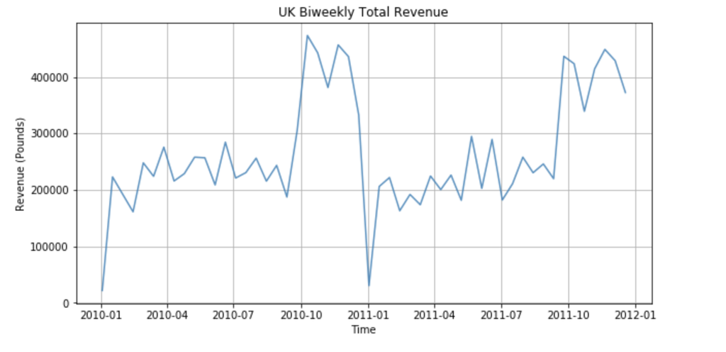

The store seems to close operations during the final week of the year. The revenue majorly rise during the final quarter of the year. Maybe, as holidays are near, more retailers tend to stockpile products as it might be cheaper for them to buy supplies around this time.

## 5.1 Benchmark Models

To test the accuracy, we need to compare our predictions with some test observation. In order to do that, we will divide our biweekly revenue data of two years (2010–2011) into train and test observations, with each comprising of 26 instances.

## a) Naive Forecast

For naive forecasts, we simply set all forecasts values to be the value of the last observation in our series. In simpler terms, it means drawing a horizontal straight line from the last observation in our train data to the forecasted period.

## c) Drift Forecast

Drift forecasting is where we calculate the average change of increase or decrease across the series and fitting it into the future.

## d) Seasonal Naive Forecast

In seasonal naive, we assume that the forecast value will be similar to the value of the observation in the same time during the last season. For example, revenue on January 1st this year would be similar to the revenue on January 1st last year based on our yearly seasonal period.

```
# Defining Baseline Forecasts Functions.# NAIVE FORECASTdef naive_f(train, test):

    # Its basically same as the last value

    forecast = test.copy()
    for i in forecast.index:
        forecast[i]=train[-1]

    return forecast# MEAN FORECASTdef mean_f(train, test):

    # Its basically same as the last value

    forecast = test.copy()
    for i in forecast.index:
        forecast[i]=test.mean()

    return forecast# DRIFT FORECASTdef drift_m(train, test):

    avg_drift = (train[-1] - train[0])/len(train)

    forecast = test.copy()

    multiplier = (train[-1] + avg_drift)

    for i in forecast.index:

        forecast[i] = multiplier

        multiplier = (forecast[i] + avg_drift)

    return forecast# SEASONAL NAIVEdef snaive(data, test, period): # Period - Period of Seasonality (Bi-Weekly)

    forecast = data.shift(period)[len(train):]
    return forecast
```

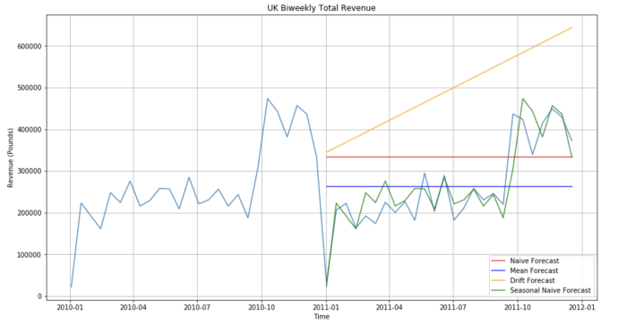

```
Accuracy of Baseline Models:

RMSE OF MEAN FORECAST IS 102203.52
RMSE OF NAIVE FORECAST IS 124127.92
RMSE OF DRIFT FORECAST IS 239147.05
RMSE OF SEASONAL NAIVE FORECAST IS 45361.79
```

Here, we can see that the root mean square error (rmse) value for our seasonal naive method is the lowest among all. Even from the graph, we are able to view that the predictions fit the test data well.

## 5.2 Walk Forward Validation For Seasonal Naive

As we see in our seasonal naive forecast of biweekly revenue stream (26 observations in an year), the period of seasonality is yearly. Therefore, the seasonal lag was 26 (T-26). What if there was another lag for which the predictions would have been more better i.e. have lower RMSE?

Lets test that.

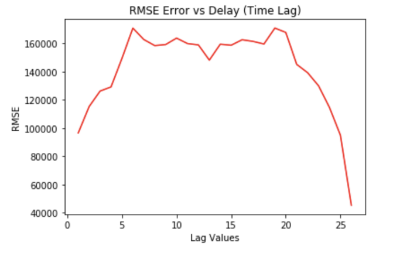

Based on the plot, we can confirm that at delay none other than 26, our seasonal naive model has the lowest rmse value.

## 5.3 Residual Analysis (Seasonal Naive)

To test whether the model has accurately fitted our forecasting models and is free of any unexplainable behaviour, there are certain criteria that residuals must meet to ensure the usability of the model. They are as follows:

a) Residuals must have a constant variance and zero mean. If not, then the model tends to be biased.

b) Residuals must have no autocorrelation. If the residuals have significant correlation with its lagged version, then the model seems to be miss out on capturing information while fitting.

c) Residuals must follow a normal distribution.

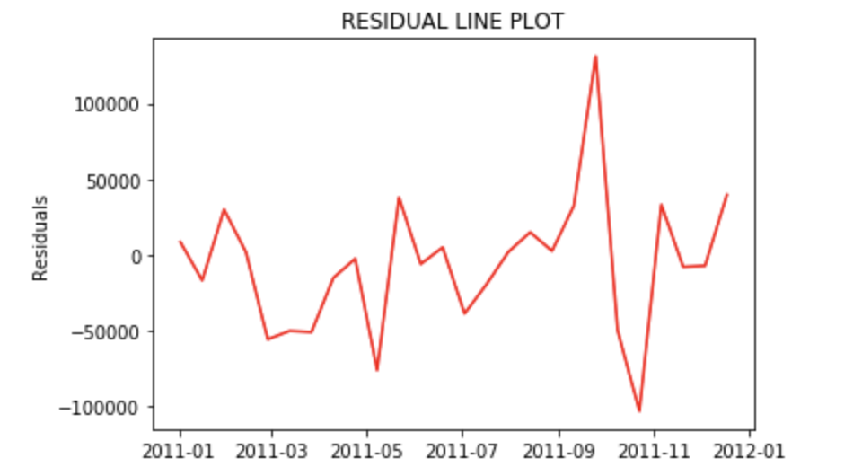

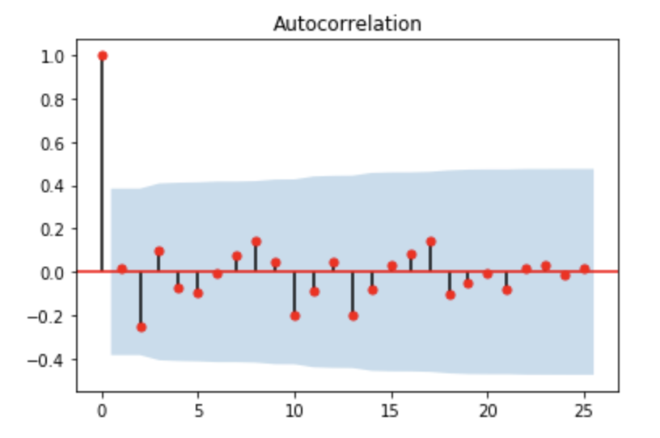

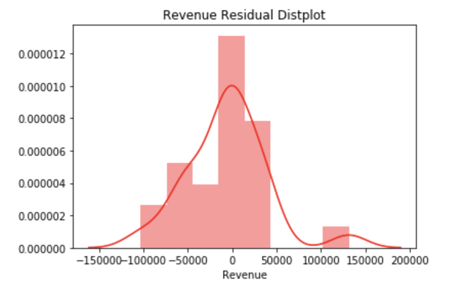

Based on the residual plots, we can see that the residuals may or may not be constant, as the variation seems to be not so constant.

Secondly, there are no significant autocorrelations among the lagged version of residuals, suggesting that the forecast shows some potential and can be further improved upon.

Lastly, the residuals are negatively skewed when we ignore the positive error on the right and could have followed a normal distribution if there were more random errors.

The number of observations used in our model are less and we must take that into account. If we had more data, the forecast would have been more reliable. Moreover, there are other forecasting techniques that can be used to improve our baseline models in order to get a reliable forecast.